# PL4246 Final Report — STARS Network Analysis

## 3.3 Build the igraph object

```r
# ── Absolutise adjacency matrix ─────────────────────────────────────────────
# Negative partial correlations arise because controlling for shared variance
# can suppress or reverse apparent associations — this is expected in pcor
# networks. For igraph path-length calculations we use absolute values so that
# all edges represent association strength (not sign) in distance computations.
stars_adj_mat_abs <- abs(stars_adj_mat)

# ── Convert to undirected weighted igraph object ─────────────────────────────
# mode = "undirected" : STARS is a cross-sectional survey; no directionality.
# weighted = TRUE     : edge weights carry the partial-correlation magnitude.
# diag = FALSE        : no self-loops (diagonal of adjacency matrix = 0).
g <- graph_from_adjacency_matrix(
  stars_adj_mat_abs,
  mode     = "undirected",
  weighted = TRUE,
  diag     = FALSE
)

# ── Sanity checks ────────────────────────────────────────────────────────────
summary(g)          # should show: weighted undirected, 51 nodes, 130 edges
```

```
## IGRAPH 0a27c83 UNW- 51 130 --
## + attr: name (v/c), weight (e/n)
```

```r
ecount(g)           # expected: 130 total edges
```

```
## [1] 130
```

```r
# Count positive vs. negative edges in the original signed matrix.
# Each undirected edge appears twice in the matrix (upper + lower triangle),
# so divide by 2 for unique edge counts.
sum(stars_adj_mat > 0)   # 184 cells → 92 unique positive edges
```

```
## [1] 184
```

```r
sum(stars_adj_mat < 0)   # 76  cells → 38 unique negative edges
```

```
## [1] 76
```

```r
# The network must form a single connected component for betweenness and
# shortest-path metrics to be well-defined across all node pairs.
components(g)$no         # expected: 1 (one connected component)
```

```
## [1] 1
```

## 3.4 Assign STARS domains

```r
# ── Map item indices to STARS domains ────────────────────────────────────────
# Domain assignments follow the original scale structure (Cruise et al., 1985).
# Item indices refer to column positions in the 51-item data frame, which
# correspond to the item numbers in the STARS scale.
#
# Domain labels (6 total):
#   TCA = Test and Class Anxiety         (8 items)
#   IA  = Interpretation Anxiety        (11 items)
#   FAH = Fear of Asking for Help        (4 items)
#   WS  = Worth of Statistics           (16 items)
#   CSC = Computation Self-Concept       (7 items)  ← focal domain
#   FST = Fear of Statistics Teachers   (5 items)

test_class_anx     <- c(1, 4, 8, 10, 13, 15, 21, 22)
interpretation_anx <- c(2, 5, 6, 7, 9, 11, 12, 14, 17, 18, 20)
fear_help          <- c(3, 16, 19, 23)
worth_stat         <- c(24, 26, 27, 28, 29, 33, 35, 36, 37,
                        40, 41, 42, 45, 47, 49, 50)
comp_self          <- c(25, 31, 34, 38, 39, 48, 51)  # item 51 = "too slow" (focal CSC node)
fear_teacher       <- c(30, 32, 43, 44, 46)

# Build a character vector of length 51 mapping each item to its domain name.
domains <- rep(NA_character_, 51)
domains[test_class_anx]     <- "Test and Class Anxiety"
domains[interpretation_anx] <- "Interpretation Anxiety"
domains[fear_help]          <- "Fear of Asking for Help"
domains[worth_stat]         <- "Worth of Statistics"
domains[comp_self]          <- "Computation Self-Concept"
domains[fear_teacher]       <- "Fear of Statistics Teachers"

# Attach domain labels as a vertex attribute in the igraph object.
V(g)$domain <- domains

# Guard: every node must have a domain label before proceeding.
stopifnot(!any(is.na(V(g)$domain)))

# Verify item counts per domain (should match the numbers in parentheses above).
table(V(g)$domain)
```

```
##
##    Computation Self-Concept     Fear of Asking for Help
##                           7                           4
## Fear of Statistics Teachers      Interpretation Anxiety
##                           5                          11
##      Test and Class Anxiety         Worth of Statistics
##                           8                          16
```

## 3.5 Convert edge weights to distances

```r
# ── Invert weights to get distances ─────────────────────────────────────────
# igraph's betweenness() and mean_distance() interpret the 'weights' argument
# as distances (larger = farther apart). However, partial correlations encode
# strength (larger = more closely associated).
#
# Inversion d = 1/w maps strong associations → short distances and weak
# associations → long distances (Siew, 2026, Ch. 4).
# Weights are already absolutised, so d is always positive.
E(g)$distance <- 1 / E(g)$weight
```

# 4 Macro-level network measures

```r
# ── Compute macro-level descriptors ─────────────────────────────────────────
# These characterise the overall network topology and are reported in Table 1
# of the paper.
#
# ASPL_weighted   : uses d = 1/|w| distances (strong ties = short paths)
# ASPL_unweighted : treats all present edges as distance = 1 (hop count)
# global_clustering : fraction of node triples that form closed triangles
# domain_assortativity : tendency for nodes to connect within their own domain
#   (> 0 = within-domain edges predominate; reported as 0.19 in the paper)

macro_results <- tibble(
  nodes                = vcount(g),
  edges                = ecount(g),
  density              = edge_density(g),
  avg_degree           = mean(degree(g)),
  ASPL_weighted        = mean_distance(g, weights = E(g)$distance),
  ASPL_unweighted      = mean_distance(g, weights = NA),
  global_clustering    = transitivity(g, type = "global"),
  diameter_weighted    = diameter(g, weights = E(g)$distance),
  degree_assortativity = assortativity_degree(g),
  domain_assortativity = assortativity_nominal(
    g, types = as.factor(V(g)$domain), directed = FALSE
  )
)
macro_results
```

| nodes | edges | density | avg_degree | ASPL_weighted | ASPL_unweighted | global_clustering | diameter_weighted | degree_assortativity | domain_assortativity |
| --- | --- | --- | --- | --- | --- | --- | --- | --- | --- |
| 51 | 130 | 0.1019608 | 5.098039 | 9.92312 | 2.710588 | 0.2174497 | 24.88095 | 0.0369359 | 0.1943635 |

## 4.1 Comparison against an Erdős–Rényi null

To assess whether the observed clustering and path length depart from random, we simulate 1,000 Erdős–Rényi (ER) networks matched on node count (n = 51) and edge count (m = 130). A psychometric network with higher clustering *and* comparable ASPL relative to the ER null is said to exhibit the small-world property (Borsboom & Cramer, 2013). The results of this comparison are summarised in Table 3 of the paper.

```r
# ── Erdős–Rényi null simulation ──────────────────────────────────────────────
# sample_gnm() generates a random graph with exactly n nodes and m edges
# (G(n,m) model). Each replicate computes unweighted ASPL and global
# clustering so we can build an empirical null distribution for both.
#
# cache = TRUE: this chunk is slow (~30 s). R Markdown will skip re-running
# it on subsequent knits if none of its inputs have changed.

n_reps  <- 1000
n_nodes <- vcount(g)   # 51
n_edges <- ecount(g)   # 130

set.seed(4246)
er_stats <- replicate(n_reps, {
  g_er <- sample_gnm(n = n_nodes, m = n_edges, directed = FALSE)
  c(
    aspl       = mean_distance(g_er, weights = NA),
    clustering = transitivity(g_er, type = "global")
  )
})

# Observed values for the STARS network (unweighted, for comparability with ER)
obs_aspl       <- mean_distance(g, weights = NA)
obs_clustering <- transitivity(g, type = "global")

# One-tailed p-values:
#   For ASPL      : proportion of ER networks with ASPL >= observed
#                   (test: is observed ASPL unusually HIGH?)
#   For clustering: proportion of ER networks with clustering >= observed
#                   (test: is observed clustering unusually HIGH?)
baseline_results <- tibble(
  measure    = c("ASPL (unweighted)", "Global clustering"),
  observed   = c(obs_aspl, obs_clustering),
  er_mean    = c(mean(er_stats["aspl", ]), mean(er_stats["clustering", ])),
  er_sd      = c(sd(er_stats["aspl", ]),   sd(er_stats["clustering", ])),
  p_one_tail = c(
    mean(er_stats["aspl", ]       >= obs_aspl),
    mean(er_stats["clustering", ] >= obs_clustering)
  )
)

# Standardised effect size: (observed - null mean) / null SD, analogous to z.
# Positive values mean the observed measure exceeds the ER expectation.
er_effect_sizes <- tibble(
  measure = c("ASPL (unweighted)", "Global clustering"),
  observed = c(obs_aspl, obs_clustering),
  er_mean  = c(mean(er_stats["aspl", ]),       mean(er_stats["clustering", ])),
  er_sd    = c(sd(er_stats["aspl", ]),         sd(er_stats["clustering", ])),
  p_one_tail = c(
    mean(er_stats["aspl", ]       >= obs_aspl),
    mean(er_stats["clustering", ] >= obs_clustering)
  )
) |>
  mutate(effect_size_z = (observed - er_mean) / er_sd)

er_effect_sizes
```

| measure | observed | er_mean | er_sd | p_one_tail | effect_size_z |
| --- | --- | --- | --- | --- | --- |
| ASPL (unweighted) | 2.7105882 | 2.5393240 | 0.03454178 | 0.001 | 4.958175 |
| Global clustering | 0.2174497 | 0.1008513 | 0.01931606 | 0.000 | 6.036343 |

The elevated clustering relative to the ER null (observed C = 0.22 vs. ER mean ≈ 0.10, p < .001) is consistent with the within-domain cohesion expected from a psychometric scale (Borsboom & Cramer, 2013). However, ASPL also exceeded the ER mean (p = .001), indicating the network does not display the classic small-world signature; significance thresholding created uneven sparsity where some domains are linked only through single bridging edges.

# 5 Domain-level descriptives

```r
# ── Degree distribution per STARS domain ─────────────────────────────────────
# Summarises how connected nodes are on average within each domain.
# Mean degree for each domain is one indicator of how embedded items
# are in the overall network structure. These values feed into Table 2.
#
# Arranged descending by mean degree so the most-connected domain appears first.
domain_summary <- tibble(
  domain = V(g)$domain,
  degree = degree(g)
) |>
  group_by(domain) |>
  summarise(
    n_nodes     = n(),
    mean_degree = mean(degree),
    sd_degree   = sd(degree),
    .groups     = "drop"
  ) |>
  arrange(desc(mean_degree))
domain_summary
```

| domain | n_nodes | mean_degree | sd_degree |
| --- | --- | --- | --- |
| Computation Self-Concept | 7 | 6.714286 | 3.817254 |
| Test and Class Anxiety | 8 | 6.250000 | 3.575712 |
| Interpretation Anxiety | 11 | 5.272727 | 2.611165 |
| Fear of Asking for Help | 4 | 4.750000 | 2.629956 |
| Worth of Statistics | 16 | 4.250000 | 2.380476 |
| Fear of Statistics Teachers | 5 | 3.600000 | 2.302173 |

# 6 Node-level centrality

## 6.1 Betweenness centrality

Weighted, normalised betweenness centrality: the proportion of shortest paths between all other pairs of nodes that pass through a given node (Siew, 2026, Ch. 7). A node with high betweenness acts as a bottleneck or structural bridge in the network. We use `weights = E(g)$distance` (inverted weights) so that strong correlations correspond to short, preferred paths. Normalisation (0–1 scale) allows comparison across networks of different sizes.

```r
# ── Weighted normalised betweenness ──────────────────────────────────────────
# weights argument takes DISTANCES (not strengths), hence E(g)$distance = 1/w.
# normalized = TRUE divides by the maximum possible betweenness for a graph of
# this size, placing values on a 0–1 scale.
btw <- betweenness(
  g,
  weights    = E(g)$distance,
  normalized = TRUE,
  directed   = FALSE
)
```

## 6.2 Bridge centrality (Jones, Ma, & McNally, 2021)

`networktools::bridge()` quantifies how much each node connects *outside* its own community (domain). Four bridge measures are returned:

- **Bridge strength**: sum of absolute edge weights from a node to nodes in other domains — the primary measure (most stable in psychometric networks; Jones et al., 2021).
- **Bridge betweenness**: counts how often a node lies on the shortest path *between* communities — used here as a convergent check.
- **Bridge closeness** and **Bridge expected influence (1-step)**: reported in the centrality table but not the primary focus.

```r
# ── Prepare community vector ─────────────────────────────────────────────────
# bridge() requires a character vector of length = n_nodes where each element
# is the community label for the corresponding node, in the SAME ORDER as the
# rows/columns of the adjacency matrix supplied to it.
community_vec <- V(g)$domain

# ── Align row/column names ───────────────────────────────────────────────────
# bridge() uses rownames and colnames to match nodes; if these are NULL or
# inconsistent, the function throws a dimension-mismatch error.
# This block ensures names are set correctly regardless of how bootnet
# returned the adjacency matrix.
node_names <- rownames(stars_adj_mat)
if (is.null(node_names)) node_names <- colnames(stars_adj_mat)
if (is.null(node_names)) node_names <- V(g)$name
rownames(stars_adj_mat) <- colnames(stars_adj_mat) <- node_names

# Guard: node names in the igraph object and the adjacency matrix must match.
stopifnot(setequal(V(g)$name, colnames(stars_adj_mat)))
stopifnot(length(community_vec) == ncol(stars_adj_mat))

# ── Compute bridge centrality ────────────────────────────────────────────────
# We pass the SIGNED adjacency matrix (stars_adj_mat, not absolutised) because
# bridge expected influence explicitly uses edge signs to model the net effect
# of a node's cross-community connections (Jones et al., 2021).
bridge_results <- bridge(
  network        = stars_adj_mat,      # signed: bridge EI requires signs
  communities    = community_vec,
  useCommunities = "all",
  directed       = FALSE,
  nodes          = NULL
)

# Extract each bridge measure as a named numeric vector (length = 51).
bridge_strength  <- bridge_results$`Bridge Strength`
bridge_betw      <- bridge_results$`Bridge Betweenness`
bridge_closeness <- bridge_results$`Bridge Closeness`
bridge_ei1       <- bridge_results$`Bridge Expected Influence (1-step)`
```

## 6.3 Tidy centrality table

```r
# ── Combine all node-level measures into one tibble ──────────────────────────
# This table is saved to tables/Table4_node_centrality.csv (Section 8) and
# is used downstream for permutation tests and figures.
#
# Column key:
#   node             : item label (matches V(g)$name)
#   domain           : STARS domain assignment
#   degree           : number of edges (unweighted)
#   betweenness      : normalised weighted betweenness (d = 1/w)
#   bridge_strength  : PRIMARY bridge measure — sum |w| to other-domain nodes
#   bridge_betw      : bridge betweenness — inter-community shortest-path count
#   bridge_closeness : bridge closeness centrality
#   bridge_ei1       : bridge expected influence (1-step, signed)

centrality_tbl <- tibble(
  node             = V(g)$name,
  domain           = V(g)$domain,
  degree           = degree(g),
  betweenness      = as.numeric(btw),
  bridge_strength  = as.numeric(bridge_strength),
  bridge_betw      = as.numeric(bridge_betw),
  bridge_closeness = as.numeric(bridge_closeness),
  bridge_ei1       = as.numeric(bridge_ei1)
)

# ── Quick inspection: top nodes on the two primary measures ──────────────────
# The most central nodes should be visually prominent in Figure 1 panels b & c.
# In the submitted paper, item t_s ("too slow", CSC) ranks first on both.

# Top 10 by bridge strength (primary bridge measure)
centrality_tbl |>
  arrange(desc(bridge_strength)) |>
  head(10)
```

| node | domain | degree | betweenness | bridge_strength | bridge_betw | bridge_closeness | bridge_ei1 |
| --- | --- | --- | --- | --- | --- | --- | --- |
| t_s | Computation Self-Concept | 14 | 0.15918367 | 3.049727 | 281 | 0.12891608 | 1.615352489 |
| nl_ | Interpretation Anxiety | 10 | 0.10040816 | 2.087565 | 48 | 0.10142069 | 0.132569090 |
| enr | Test and Class Anxiety | 11 | 0.04897959 | 2.056560 | 49 | 0.10255008 | 0.504732291 |
| dat | Interpretation Anxiety | 8 | 0.06938776 | 1.804603 | 38 | 0.10347077 | 0.352463171 |
| fn_ | Test and Class Anxiety | 9 | 0.07673469 | 1.624784 | 86 | 0.09844253 | -0.658055477 |
| df_ | Test and Class Anxiety | 9 | 0.07102041 | 1.543082 | 35 | 0.09863517 | 0.004842007 |
| mt2 | Computation Self-Concept | 9 | 0.03673469 | 1.448660 | 52 | 0.10096484 | 0.443200801 |
| mrn | Test and Class Anxiety | 6 | 0.04000000 | 1.397211 | 116 | 0.10281076 | 1.397211227 |
| cls | Test and Class Anxiety | 8 | 0.04653061 | 1.335394 | 65 | 0.10095860 | -0.358341961 |
| hlp_c | Fear of Asking for Help | 7 | 0.06040816 | 1.322072 | 54 | 0.09227715 | -0.102624668 |

```r
# Top 10 by betweenness (general network centrality)
centrality_tbl |>
  arrange(desc(betweenness)) |>
  head(10)
```

| node | domain | degree | betweenness | bridge_strength | bridge_betw | bridge_closeness | bridge_ei1 |
| --- | --- | --- | --- | --- | --- | --- | --- |
| t_s | Computation Self-Concept | 14 | 0.15918367 | 3.0497270 | 281 | 0.12891608 | 1.615352489 |
| nl_ | Interpretation Anxiety | 10 | 0.10040816 | 2.0875653 | 48 | 0.10142069 | 0.132569090 |
| dnt_w | Worth of Statistics | 6 | 0.09632653 | 1.0096455 | 79 | 0.07095301 | -0.444488417 |
| fn_ | Test and Class Anxiety | 9 | 0.07673469 | 1.6247837 | 86 | 0.09844253 | -0.658055477 |
| prn | Interpretation Anxiety | 6 | 0.07591837 | 0.9618040 | 49 | 0.08986364 | 0.029320252 |
| df_ | Test and Class Anxiety | 9 | 0.07102041 | 1.5430818 | 35 | 0.09863517 | 0.004842007 |
| dat | Interpretation Anxiety | 8 | 0.06938776 | 1.8046030 | 38 | 0.10347077 | 0.352463171 |
| phl | Worth of Statistics | 8 | 0.06204082 | 1.2956374 | 108 | 0.10493370 | 0.107231429 |
| hlp_c | Fear of Asking for Help | 7 | 0.06040816 | 1.3220724 | 54 | 0.09227715 | -0.102624668 |
| brn | Computation Self-Concept | 4 | 0.05959184 | 0.5326995 | 138 | 0.11422003 | 0.532699452 |

# 7 Domain-level comparisons

## 7.1 Descriptive means per domain

```r
# ── Aggregate centrality measures by STARS domain ────────────────────────────
# Produces Table 2 in the paper: mean degree, betweenness, bridge strength,
# and bridge betweenness per domain.
#
# Arranged descending by mean bridge strength so the highest-bridging domain
# (Computation Self-Concept) appears at the top.

domain_centrality <- centrality_tbl |>
  group_by(domain) |>
  summarise(
    n              = n(),
    mean_btw       = mean(betweenness),
    mean_bstrength = mean(bridge_strength),
    mean_bbetween  = mean(bridge_betw),
    .groups        = "drop"
  ) |>
  arrange(desc(mean_bstrength))
domain_centrality
```

| domain | n | mean_btw | mean_bstrength | mean_bbetween |
| --- | --- | --- | --- | --- |
| Computation Self-Concept | 7 | 0.05201166 | 1.1944352 | 92.57143 |
| Test and Class Anxiety | 8 | 0.03979592 | 1.1163792 | 50.00000 |
| Fear of Asking for Help | 4 | 0.03061224 | 0.9033753 | 47.75000 |
| Interpretation Anxiety | 11 | 0.04296846 | 0.8800355 | 35.63636 |
| Fear of Statistics Teachers | 5 | 0.01224490 | 0.7046555 | 23.40000 |
| Worth of Statistics | 16 | 0.02841837 | 0.5860928 | 34.93750 |

## 7.2 Assumption tests

Before choosing between a parametric t-test and a permutation test, we check two key assumptions: normality (Shapiro–Wilk) and variance equality (Levene). These are reported in the Methods section of the paper as the justification for using a label-permutation test.

```r
# ── Shapiro–Wilk normality tests ─────────────────────────────────────────────
# Tested on: (a) the full 51-node distribution, and (b) the CSC subgroup (n=7).
# Significant departures from normality (p < .05) in either group violate the
# normality assumption required for a parametric t-test.
#
# Reported in the paper: Ws = 0.78–0.93, all ps < .01 for the full distribution;
# betweenness and bridge betweenness also violated normality within CSC.

normality_checks <- tibble(
  measure = c("Betweenness", "Bridge Strength", "Bridge Betweenness"),

  # Full distribution (all 51 nodes)
  W_full = c(
    shapiro.test(centrality_tbl$betweenness)$statistic,
    shapiro.test(centrality_tbl$bridge_strength)$statistic,
    shapiro.test(centrality_tbl$bridge_betw)$statistic
  ),
  p_full = c(
    shapiro.test(centrality_tbl$betweenness)$p.value,
    shapiro.test(centrality_tbl$bridge_strength)$p.value,
    shapiro.test(centrality_tbl$bridge_betw)$p.value
  ),

  # CSC subgroup only (n = 7)
  W_csc = c(
    shapiro.test(centrality_tbl$betweenness[centrality_tbl$domain == "Computation Self-Concept"])$statistic,
    shapiro.test(centrality_tbl$bridge_strength[centrality_tbl$domain == "Computation Self-Concept"])$statistic,
    shapiro.test(centrality_tbl$bridge_betw[centrality_tbl$domain == "Computation Self-Concept"])$statistic
  ),
  p_csc = c(
    shapiro.test(centrality_tbl$betweenness[centrality_tbl$domain == "Computation Self-Concept"])$p.value,
    shapiro.test(centrality_tbl$bridge_strength[centrality_tbl$domain == "Computation Self-Concept"])$p.value,
    shapiro.test(centrality_tbl$bridge_betw[centrality_tbl$domain == "Computation Self-Concept"])$p.value
  )
)

normality_checks
```

| measure | W_full | p_full | W_csc | p_csc |
| --- | --- | --- | --- | --- |
| Betweenness | 0.8853884 | 1.416681e-04 | 0.7457122 | 0.01144186 |
| Bridge Strength | 0.9340196 | 7.121375e-03 | 0.8125275 | 0.05436618 |
| Bridge Betweenness | 0.7776442 | 2.266610e-07 | 0.7595052 | 0.01593069 |

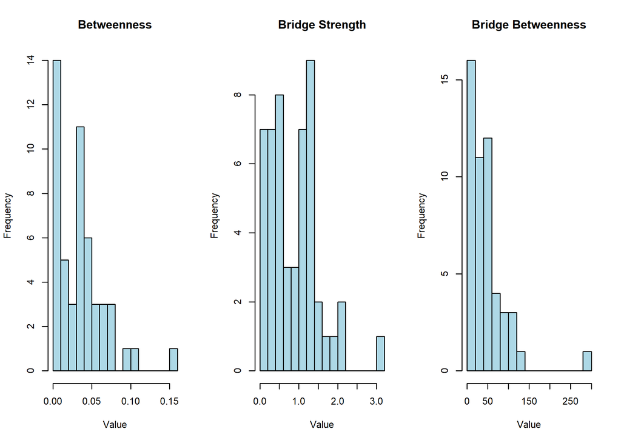

```r
# ── Visual inspection: distribution shape ────────────────────────────────────
# Histograms for all three centrality measures reveal the right-skewed
# distributions that further justify the non-parametric approach.
par(mfrow = c(1, 3))

hist(centrality_tbl$betweenness,
     main = "Betweenness", xlab = "Value",
     col = "lightblue", breaks = 15)

hist(centrality_tbl$bridge_strength,
     main = "Bridge Strength", xlab = "Value",
     col = "lightblue", breaks = 15)

hist(centrality_tbl$bridge_betw,
     main = "Bridge Betweenness", xlab = "Value",
     col = "lightblue", breaks = 15)
```

```r
par(mfrow = c(1, 1))

# ── Levene's test: equality of variances ─────────────────────────────────────
# Tests whether the CSC group and the rest of the nodes have equal variance on
# each centrality measure — a second assumption required for a standard t-test.
# If violated, this provides additional justification for the permutation approach.

# Create a binary grouping variable: CSC vs. all other domains
centrality_tbl <- centrality_tbl |>
  mutate(is_csc = ifelse(domain == "Computation Self-Concept", "CSC", "Other"))

levene_results <- tibble(
  measure = c("Betweenness", "Bridge Strength", "Bridge Betweenness"),
  F_stat = c(
    leveneTest(betweenness     ~ is_csc, data = centrality_tbl)$`F value`[1],
    leveneTest(bridge_strength ~ is_csc, data = centrality_tbl)$`F value`[1],
    leveneTest(bridge_betw     ~ is_csc, data = centrality_tbl)$`F value`[1]
  ),
  p_value = c(
    leveneTest(betweenness     ~ is_csc, data = centrality_tbl)$`Pr(>F)`[1],
    leveneTest(bridge_strength ~ is_csc, data = centrality_tbl)$`Pr(>F)`[1],
    leveneTest(bridge_betw     ~ is_csc, data = centrality_tbl)$`Pr(>F)`[1]
  )
)

levene_results
```

| measure | F_stat | p_value |
| --- | --- | --- |
| Betweenness | 1.1265404 | 0.29371801 |
| Bridge Strength | 0.6245409 | 0.43317297 |
| Bridge Betweenness | 3.3838827 | 0.07189911 |

## 7.3 Permutation test: Computation Self-Concept vs. rest

A label-permutation test was chosen over a parametric t-test for three reasons: the CSC group is small (n = 7), Shapiro–Wilk tests showed normality violations across all three measures, and the permutation framework directly operationalises the null hypothesis of interest — that domain labels are exchangeable with respect to centrality. The implementation follows Marin (2019).

The test asks: if domain membership is irrelevant, how often would we observe a mean-difference at least as large as the one we actually found?

```r
# ── Label-permutation test function ──────────────────────────────────────────
# Arguments:
#   values       : numeric vector of centrality scores (length = n_nodes = 51)
#   group_labels : character vector of domain labels (same length as values)
#   target_label : the focal domain to compare against all others ("Computation
#                  Self-Concept" in this analysis)
#   n_perm       : number of permutations (10,000; Marin, 2019)
#
# Returns a list with the observed mean difference, two-tailed p-value,
# and null distribution statistics.
#
# Two-tailed p-value: proportion of null differences whose absolute value is
# at least as large as the absolute observed difference.

permutation_test <- function(values, group_labels, target_label,
                             n_perm = 10000) {
  obs_diff <- mean(values[group_labels == target_label]) -
              mean(values[group_labels != target_label])

  perm_diffs <- replicate(n_perm, {
    shuffled <- sample(group_labels)
    mean(values[shuffled == target_label]) -
      mean(values[shuffled != target_label])
  })

  p_val <- mean(abs(perm_diffs) >= abs(obs_diff))

  list(
    observed_difference = obs_diff,
    p_value             = p_val,
    n_permutations      = n_perm,
    null_mean           = mean(perm_diffs),
    null_sd             = sd(perm_diffs)
  )
}

# ── Run permutation tests for each centrality measure ────────────────────────
# cache = TRUE: permutation tests are slow (10,000 iterations × 3 measures).
# Results in the paper: bridge betweenness p = .012 (significant);
# betweenness p = .134 and bridge strength p = .131 (non-significant).

perm_btw <- permutation_test(
  centrality_tbl$betweenness,
  centrality_tbl$domain,
  "Computation Self-Concept"
)
perm_bstrength <- permutation_test(
  centrality_tbl$bridge_strength,
  centrality_tbl$domain,
  "Computation Self-Concept"
)
perm_bbetween <- permutation_test(
  centrality_tbl$bridge_betw,
  centrality_tbl$domain,
  "Computation Self-Concept"
)

# ── Summary table (Table 3 in paper) ─────────────────────────────────────────
tibble(
  measure       = c("Betweenness", "Bridge Strength", "Bridge Betweenness"),
  observed_diff = c(perm_btw$observed_difference,
                    perm_bstrength$observed_difference,
                    perm_bbetween$observed_difference),
  p_value       = c(perm_btw$p_value,
                    perm_bstrength$p_value,
                    perm_bbetween$p_value)
)
```

| measure | observed_diff | p_value |
| --- | --- | --- |
| Betweenness | 0.01952558 | 0.1337 |
| Bridge Strength | 0.39612413 | 0.1308 |
| Bridge Betweenness | 54.86688312 | 0.0118 |

```r
# ── Effect sizes: Cohen's d (supplementary) ───────────────────────────────────
# Pooled-SD Cohen's d for unequal group sizes (CSC n=7, rest n=44).
# Reported alongside permutation results as a standardised effect size.
cohens_d <- function(values, group_labels, target_label) {
  g1 <- values[group_labels == target_label]
  g2 <- values[group_labels != target_label]
  n1 <- length(g1); n2 <- length(g2)
  pooled_sd <- sqrt(((n1 - 1) * var(g1) + (n2 - 1) * var(g2)) / (n1 + n2 - 2))
  (mean(g1) - mean(g2)) / pooled_sd
}

tibble(
  measure = c("Betweenness", "Bridge Strength", "Bridge Betweenness"),
  observed_diff = c(perm_btw$observed_difference,
                    perm_bstrength$observed_difference,
                    perm_bbetween$observed_difference),
  p_value = c(perm_btw$p_value,
              perm_bstrength$p_value,
              perm_bbetween$p_value),
  cohens_d = c(
    cohens_d(centrality_tbl$betweenness,    centrality_tbl$domain, "Computation Self-Concept"),
    cohens_d(centrality_tbl$bridge_strength, centrality_tbl$domain, "Computation Self-Concept"),
    cohens_d(centrality_tbl$bridge_betw,    centrality_tbl$domain, "Computation Self-Concept")
  )
)
```

| measure | observed_diff | p_value | cohens_d |
| --- | --- | --- | --- |
| Betweenness | 0.01952558 | 0.1337 | 0.6220210 |
| Bridge Strength | 0.39612413 | 0.1308 | 0.6211592 |
| Bridge Betweenness | 54.86688312 | 0.0118 | 1.2168880 |

## 7.4 Mann–Whitney U test (convergent check)

A Mann–Whitney U test is included as a non-parametric convergent check. It is *not* the primary test (the permutation test is) because it evaluates rank distributions rather than mean differences, which is the direct quantity of interest. Both tests lead to the same substantive conclusions.

```r
# ── Mann–Whitney U tests: CSC vs. rest ───────────────────────────────────────
# Two-sided tests; exact = FALSE because of ties in ranked data.
# Effect size: rank-biserial correlation r — analogous to Cohen's d for
# nonparametric tests. r > 0 indicates CSC ranks higher than the rest.

mw_btw <- wilcox.test(
  centrality_tbl$betweenness[centrality_tbl$domain == "Computation Self-Concept"],
  centrality_tbl$betweenness[centrality_tbl$domain != "Computation Self-Concept"],
  alternative = "two.sided",
  exact = FALSE
)

mw_bstrength <- wilcox.test(
  centrality_tbl$bridge_strength[centrality_tbl$domain == "Computation Self-Concept"],
  centrality_tbl$bridge_strength[centrality_tbl$domain != "Computation Self-Concept"],
  alternative = "two.sided",
  exact = FALSE
)

mw_bbetween <- wilcox.test(
  centrality_tbl$bridge_betw[centrality_tbl$domain == "Computation Self-Concept"],
  centrality_tbl$bridge_betw[centrality_tbl$domain != "Computation Self-Concept"],
  alternative = "two.sided",
  exact = FALSE
)

# ── Rank-biserial correlation (effect size) ───────────────────────────────────
# Formula: r = (U1 - U2) / (n1 * n2)
# where U1 = Wilcoxon statistic for CSC vs rest, U2 = n1*n2 - U1
# r > 0: CSC has higher ranks (stronger centrality) than the rest.
n1 <- sum(centrality_tbl$domain == "Computation Self-Concept")  # n = 7
n2 <- sum(centrality_tbl$domain != "Computation Self-Concept")  # n = 44

rank_biserial_correct <- function(U, n1, n2) {
  U2 <- n1 * n2 - U
  (U - U2) / (n1 * n2)
}

tibble(
  measure       = c("Betweenness", "Bridge Strength", "Bridge Betweenness"),
  U             = c(mw_btw$statistic, mw_bstrength$statistic, mw_bbetween$statistic),
  p_value       = c(mw_btw$p.value,   mw_bstrength$p.value,   mw_bbetween$p.value),
  rank_biserial = rank_biserial_correct(
    c(mw_btw$statistic, mw_bstrength$statistic, mw_bbetween$statistic),
    n1, n2
  )
)
```

| measure | U | p_value | rank_biserial |
| --- | --- | --- | --- |
| Betweenness | 189 | 0.34351295 | 0.2272727 |
| Bridge Strength | 196 | 0.25536098 | 0.2727273 |
| Bridge Betweenness | 226 | 0.04966683 | 0.4675325 |

## 7.5 Direct edge counts between CSC and the two interpersonal domains

```r
# ── Descriptive adjacency check ───────────────────────────────────────────────
# Tests the specific mechanistic hypothesis from the paper: does CSC sit between
# Fear of Statistics Teachers (FST) and Fear of Asking for Help (FAH)?
#
# We count direct edges (non-zero adjacency entries) between each pair of domains.
# If CSC connects to both FST and FAH while FST and FAH connect little to each
# other, that is face-valid structural evidence for a bridging role.
#
# Reported in the paper:
#   CSC–FST: 5 direct edges (out of 7 × 5 = 35 possible)
#   CSC–FAH: 2 direct edges (out of 7 × 4 = 28 possible)
#   FST–FAH: 1 direct edge  (out of 5 × 4 = 20 possible)

csc_nodes <- V(g)$name[V(g)$domain == "Computation Self-Concept"]
fst_nodes  <- V(g)$name[V(g)$domain == "Fear of Statistics Teachers"]
fah_nodes  <- V(g)$name[V(g)$domain == "Fear of Asking for Help"]

# Count non-zero entries in each inter-domain submatrix.
# Using the absolutised matrix so that negative edges are also counted.
csc_fst_edges <- sum(stars_adj_mat_abs[csc_nodes, fst_nodes] > 0)
csc_fah_edges <- sum(stars_adj_mat_abs[csc_nodes, fah_nodes] > 0)
fst_fah_edges <- sum(stars_adj_mat_abs[fst_nodes, fah_nodes] > 0)

tibble(
  connection         = c("CSC — FST", "CSC — FAH", "FST — FAH (direct)"),
  n_edges            = c(csc_fst_edges, csc_fah_edges, fst_fah_edges)
)
```

| connection | n_edges |
| --- | --- |
| CSC — FST | 5 |
| CSC — FAH | 2 |
| FST — FAH (direct) | 1 |

# 8 Network robustness checks

Psychometric networks are estimated from data and therefore carry uncertainty. The bootnet package (Epskamp et al., 2018) provides two complementary assessments: a non-parametric bootstrap for **edge-weight precision** and a case-drop bootstrap for **centrality stability**. Epskamp et al. (2018) recommend a CS-coefficient > 0.25 as a minimum threshold for interpretability and > 0.50 for strong confidence.

## 8.1 Edge-weight bootstrap

```r
# ── Non-parametric edge-weight bootstrap ─────────────────────────────────────
# Resamples respondents with replacement (1,000 iterations) to estimate the
# confidence interval around each edge weight. A narrow CI indicates the edge
# is estimated precisely; wide overlap between two edges' CIs indicates that
# their relative ordering is uncertain.
#
# Statistics requested:
#   "edge"     : bootstrapped CI for each individual edge weight
#   "strength" : bootstrapped CI for node strength (sum of |edge weights|)
#
# nCores = 1: avoids parallel processing issues on some systems; increase to
#   nCores = parallel::detectCores() - 1 to speed up if needed.
#
# NOTE: This chunk takes 1–3 minutes on a modern laptop (cache = TRUE).

set.seed(4246)
boot_edge <- bootnet(stars_matrix, nBoots = 1000, nCores = 1,
                     type       = "nonparametric",
                     statistics = c("edge", "strength"))
```

[output not shown]

[output not shown]

```r
# Preview the first 10 rows of edge-weight bootstrap summary
summary(boot_edge, statistics = "edge")[1:10, ]
```

| type | id | node1 | node2 | sample | mean | sd | CIlower | CIupper | q2.5 | q97.5 | q2.5_non0 | mean_non0 | q97.5_non0 | var_non0 | sd_non0 | prop0 |
| --- | --- | --- | --- | --- | --- | --- | --- | --- | --- | --- | --- | --- | --- | --- | --- | --- |
| edge | actual_life--brains | actual_life | brains | 0.0000000 | -0.004098314 | 0.1135128 | -0.2270255 | 0.2270255 | -0.2992936 | 0.2847309 | -0.4060708 | -0.02593869 | 0.3850545 | 0.081418828 | 0.28533985 | 0.842 |
| edge | actual_life--cognitive | actual_life | cognitive | 0.0000000 | 0.048190829 | 0.1251006 | -0.2502011 | 0.2502011 | 0.0000000 | 0.3716302 | -0.2957837 | 0.24462350 | 0.4955618 | 0.031470655 | 0.17739970 | 0.803 |
| edge | actual_life--dont_like | actual_life | dont_like | 0.0000000 | 0.073035565 | 0.1460093 | -0.2920185 | 0.2920185 | 0.0000000 | 0.4070691 | -0.2553064 | 0.25899137 | 0.4806450 | 0.027459071 | 0.16570779 | 0.718 |
| edge | actual_life--dont_want | actual_life | dont_want | 0.0000000 | -0.008137935 | 0.1251716 | -0.2503432 | 0.2503432 | -0.3170146 | 0.2956109 | -0.4233160 | -0.04398884 | 0.4152321 | 0.083481044 | 0.28893086 | 0.815 |
| edge | actual_life--grind | actual_life | grind | 0.0000000 | 0.069971075 | 0.1430096 | -0.2860192 | 0.2860192 | 0.0000000 | 0.4023642 | -0.3055958 | 0.25079239 | 0.4663409 | 0.027982151 | 0.16727866 | 0.721 |
| edge | actual_life--mathematical | actual_life | mathematical | 0.0000000 | -0.038066335 | 0.1155395 | -0.2310791 | 0.2310791 | -0.3289826 | 0.2142465 | -0.4160584 | -0.20465771 | 0.3149326 | 0.037808187 | 0.19444327 | 0.814 |
| edge | actual_life--mathematical2 | actual_life | mathematical2 | 0.0000000 | 0.091433793 | 0.1450503 | -0.2901006 | 0.2901006 | 0.0000000 | 0.4033521 | 0.2161771 | 0.28573060 | 0.4875562 | 0.010198315 | 0.10098671 | 0.680 |
| edge | actual_life--more_time | actual_life | more_time | 0.2290294 | 0.177141232 | 0.1758566 | -0.1226838 | 0.5807425 | 0.0000000 | 0.4876216 | 0.2205327 | 0.32384138 | 0.5109720 | 0.008988949 | 0.09481007 | 0.453 |
| edge | actual_life--natural_ability | actual_life | natural_ability | 0.0000000 | 0.029228991 | 0.1130951 | -0.2261902 | 0.2261902 | -0.2392042 | 0.3320135 | -0.3377939 | 0.17714540 | 0.4434188 | 0.051550378 | 0.22704708 | 0.835 |
| edge | actual_life--never_use | actual_life | never_use | 0.0000000 | 0.037886462 | 0.1147981 | -0.2295961 | 0.2295961 | 0.0000000 | 0.3431213 | -0.2808246 | 0.21899689 | 0.4567744 | 0.036649919 | 0.19144168 | 0.827 |

A narrow bootstrapped CI around an edge indicates that the edge weight is estimated precisely; large overlap between the CIs of two edges means their relative ordering is uncertain.

## 8.2 Centrality stability (case-drop bootstrap)

```r
# ── Case-drop centrality stability ───────────────────────────────────────────
# Progressively removes respondents (in 10% increments) and re-estimates the
# network on each subsample (1,000 iterations per step). corStability()
# computes the CS-coefficient for each centrality measure: the largest
# fraction of cases that can be dropped while maintaining r ≥ 0.70 between
# the subsample centrality ordering and the full-sample ordering.
#
# Thresholds (Epskamp et al., 2018):
#   CS > 0.50 : strong confidence in centrality ordering
#   CS > 0.25 : minimum threshold for interpretability
#   CS ≤ 0.25 : rankings should NOT be interpreted
#
# Expected result here: CS ≈ 0.00 for betweenness and closeness, 0.053 for
# strength — all below 0.25. This is a known consequence of the low n/p ratio
# (132 respondents / 51 items ≈ 2.6). Removing even a small number of
# respondents makes the partial-correlation matrix non-positive-definite,
# preventing re-estimation. Interpret individual node rankings descriptively only.
#
# NOTE: This chunk takes 2–5 minutes (cache = TRUE).

set.seed(4246)
boot_case <- bootnet(stars_matrix, nBoots = 1000, nCores = 1,
                     type       = "case",
                     statistics = c("strength", "betweenness", "closeness"))
```

[output not shown]

[output cut: 467 more lines]

[output not shown]

[output not shown]

```r
# CS-coefficient: one value per centrality measure
cs_coef <- corStability(boot_case)
```

```
## === Correlation Stability Analysis ===
##
## Sampling levels tested:
##   nPerson Drop%   n
## 1      43  67.4   1
## 2      54  59.1 119
## 3      64  51.5 124
## 4      74  43.9 113
## 5      84  36.4 136
## 6      95  28.0 113
## 7     105  20.5 137
## 8     115  12.9 128
## 9     125   5.3 129
##
## Maximum drop proportions to retain correlation of 0.7 in at least 95% of the samples:
##
## betweenness: 0
##   - For more accuracy, run bootnet(..., caseMin = 0, caseMax = 0.053)
##
## closeness: 0
##   - For more accuracy, run bootnet(..., caseMin = 0, caseMax = 0.053)
##
## strength: 0.053 (CS-coefficient is lowest level tested)
##   - For more accuracy, run bootnet(..., caseMin = 0, caseMax = 0.129)
##
## Accuracy can also be increased by increasing both 'nBoots' and 'caseN'.
```

```r
cs_coef
```

```
## betweenness   closeness    strength
##   0.0000000   0.0000000   0.0530303
```

The CS-coefficient is the largest proportion of cases that can be dropped while maintaining a correlation of at least 0.70 (with 95% probability) between the centrality ordering in the subsample and the full sample. Betweenness is known to be less stable than strength in small-sample psychometric networks (Bringmann et al., 2019); results based on betweenness should be interpreted with this caveat in mind.

# 9 Figures for the report

```r
# ── Shared aesthetics used across all three panels of Figure 1 ───────────────
# Saving figures to figures/ keeps the working directory tidy and makes it
# easy for a marker to locate all visual outputs.
dir.create("figures", showWarnings = FALSE)

# Colour palette: one distinctive colour per STARS domain.
# These same colours are used in Figure 1 (igraph plots) and Figure 2 (ggplot).
domain_colors <- c(
  "Test and Class Anxiety"       = "#E41A1C",
  "Interpretation Anxiety"       = "#377EB8",
  "Fear of Asking for Help"      = "#4DAF4A",
  "Worth of Statistics"          = "#984EA3",
  "Computation Self-Concept"     = "#FF7F00",
  "Fear of Statistics Teachers"  = "#FFD700"
)

# Fruchterman–Reingold layout — positions are fixed with set.seed(4246) so
# all three panels of Figure 1 share the same spatial coordinates, enabling
# direct visual comparison of domain vs. betweenness vs. bridge strength.
set.seed(4246)
layout_fr <- layout_with_fr(g, weights = E(g)$weight)

# Node-size scaling helper:
# Maps any positive numeric vector to the interval [min_size, max_size].
# Used in panels b and c to scale node size by betweenness and bridge strength.
scale_node <- function(x, min_size = 3, max_size = 14) {
  if (max(x) == min(x)) return(rep((min_size + max_size) / 2, length(x)))
  min_size + (x - min(x)) / (max(x) - min(x)) * (max_size - min_size)
}

size_btw  <- scale_node(centrality_tbl$betweenness)
size_brid <- scale_node(centrality_tbl$bridge_strength)
```

## 9.1 Figure 1 — Network topology panels (domain / betweenness / bridge strength)

```r
# ── Figure 1: Three-panel igraph visualisation ───────────────────────────────
# All three panels share the same Fruchterman–Reingold layout so spatial
# positions are directly comparable across panels.
#
# Panel (a): node colour = STARS domain.
# Panel (b): node size ∝ betweenness centrality; labels shown for identification.
# Panel (c): node size ∝ bridge strength; labels shown for identification.
#
# Edge width ∝ absolute partial correlation (E(g)$weight from absolutised matrix).
# Edge colour: uniform grey (sign information is secondary to structural layout here).
#
# Saved as a high-resolution PNG (300 dpi) for inclusion in the report.

vlabels <- V(g)$name

# Re-compute layout and sizes here in case this chunk is run in isolation
# (i.e., without the setup-figures chunk cached in the environment).
set.seed(4246)
layout_fr <- layout_with_fr(g, weights = E(g)$weight)

scale_node <- function(x, min_size = 3, max_size = 14) {
  if (max(x) == min(x)) return(rep((min_size + max_size) / 2, length(x)))
  min_size + (x - min(x)) / (max(x) - min(x)) * (max_size - min_size)
}
size_btw  <- scale_node(centrality_tbl$betweenness)
size_brid <- scale_node(centrality_tbl$bridge_strength)

# Note: g was built from the absolutised matrix, so E(g)$weight is always > 0.
# To recover edge sign for colouring, we would index back into stars_adj_mat,
# but for this figure a uniform grey is used for visual clarity.
edge_weights_raw <- stars_adj_mat[as_edgelist(g)]
edge_colour <- ifelse(E(g)$weight > 0, "grey60", "#E07070")

png("figures/Figure1_combined_network.png", width = 4800, height = 1800, res = 300)
par(mfrow = c(1, 3), mar = c(1, 1, 3, 1))

# Panel (a): colour by STARS domain
plot(g, layout = layout_fr, vertex.label = NA, vertex.size = 7,
     vertex.color = domain_colors[V(g)$domain], vertex.frame.color = "white",
     edge.width = E(g)$weight * 6, edge.color = "grey80",
     main = "(a) Network by STARS Domain")
legend("bottomleft", legend = names(domain_colors), fill = domain_colors, bty = "n", cex = 0.7)

# Panel (b): node size = betweenness centrality
plot(g, layout = layout_fr, vertex.label = vlabels, vertex.size = size_btw,
     vertex.color = domain_colors[V(g)$domain], vertex.frame.color = "white",
     edge.width = E(g)$weight * 6, edge.color = "grey80",
     main = "(b) Node size = Betweenness")

# Panel (c): node size = bridge strength
plot(g, layout = layout_fr, vertex.label = vlabels, vertex.size = size_brid,
     vertex.color = domain_colors[V(g)$domain], vertex.frame.color = "white",
     edge.width = E(g)$weight * 6, edge.color = "grey80",
     main = "(c) Node size = Bridge Strength")

dev.off()
```

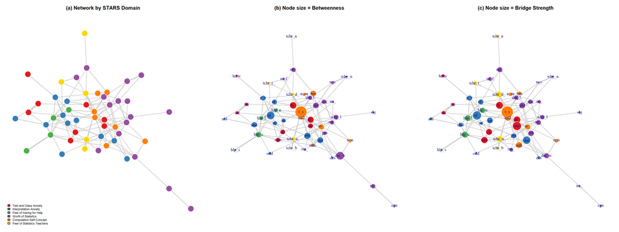

```r
# Display the saved figure inline in the rendered HTML document.
knitr::include_graphics("figures/Figure1_combined_network.png")
```

## 9.2 Figure 2 — Standardised centrality z-scores by node

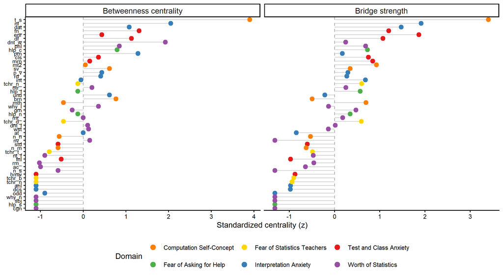

```r
# ── Figure 2: Lollipop chart of standardised centrality z-scores ─────────────
# Standardises betweenness and bridge strength to z-scores so the two measures
# can be displayed on comparable scales within a faceted plot.
#
# Nodes are ordered by their mean z-score (across measures) via reorder(),
# placing the most central nodes at the top of each panel.
#
# Colour = STARS domain, matching Figure 1.
# The item t_s ("too slow", CSC, orange) is expected to appear at the top of
# both panels, as reported in the paper.

centrality_std <- centrality_tbl |>
  mutate(
    btw_z  = as.numeric(scale(betweenness)),
    bstr_z = as.numeric(scale(bridge_strength))
  )

plot_data2 <- centrality_std |>
  select(node, domain, btw_z, bstr_z) |>
  pivot_longer(cols      = c(btw_z, bstr_z),
               names_to  = "measure",
               values_to = "z_score") |>
  mutate(
    measure = case_when(
      measure == "btw_z"  ~ "Betweenness centrality",
      measure == "bstr_z" ~ "Bridge strength",
      TRUE ~ measure
    ),
    node = reorder(node, z_score, FUN = mean)
  )

p3 <- ggplot(plot_data2,
             aes(x = node, y = z_score, colour = domain)) +
  geom_hline(yintercept = 0, linetype = "dashed", colour = "grey70") +
  geom_segment(aes(xend = node, y = 0, yend = z_score),
               colour = "grey80", linewidth = 0.4) +
  geom_point(size = 2.5) +
  facet_wrap(~ measure, scales = "free_x") +
  scale_colour_manual(values = domain_colors, name = "Domain") +
  coord_flip() +
  labs(x = NULL, y = "Standardized centrality (z)", title = NULL) +
  theme_classic(base_size = 10) +
  theme(
    axis.text.y     = element_text(size = 7),
    legend.position = "bottom",
    legend.text     = element_text(size = 8),
    strip.text      = element_text(face = "plain", size = 10)
  ) +
  guides(colour = guide_legend(nrow = 2, override.aes = list(size = 3)))

ggsave("figures/Figure2_centrality_by_node.png",
       plot = p3, width = 9, height = 7, dpi = 300)
p3
```

# 10 Save outputs

```r
# ── Create output directories ────────────────────────────────────────────────
# tables/ : CSV exports of all four results tables (reproducible without re-running)
# output/ : saved R objects for the marker to load directly (avoids re-running
#           the slow estimation pipeline)
dir.create("tables", showWarnings = FALSE)
dir.create("output", showWarnings = FALSE)

# ── Tables (CSV) ─────────────────────────────────────────────────────────────
# Table 1 (macro_results)     : overall network descriptives
# Table 2 (domain_summary)    : domain size and mean degree
# Table 3 (domain_centrality) : domain-level centrality means (Table 2 in paper)
# Table 4 (centrality_tbl)    : full node-level centrality measures
write.csv(macro_results,     "tables/Table1_macro_results.csv",     row.names = FALSE)
write.csv(domain_summary,    "tables/Table2_domain_summary.csv",    row.names = FALSE)
write.csv(domain_centrality, "tables/Table3_domain_centrality.csv", row.names = FALSE)
write.csv(centrality_tbl,    "tables/Table4_node_centrality.csv",   row.names = FALSE)

# ── R objects (RDS) ──────────────────────────────────────────────────────────
# stars_igraph.rds   : igraph object (absolute weights, domain attributes)
# stars_bootnet.rds  : bootnet network object (needed to re-run bootnet plots)
# bridge_results.rds : full bridge() output (all four bridge measures)
#
# A marker can load any of these with:
#   g              <- readRDS("output/stars_igraph.rds")
#   stars_matrix   <- readRDS("output/stars_bootnet.rds")
#   bridge_results <- readRDS("output/bridge_results.rds")
saveRDS(g,              "output/stars_igraph.rds")
saveRDS(stars_matrix,   "output/stars_bootnet.rds")
saveRDS(bridge_results, "output/bridge_results.rds")

# ── Session info ─────────────────────────────────────────────────────────────
# Records the exact R version and package versions used, supporting
# reproducibility. Also displayed at the end of this document.
writeLines(capture.output(sessionInfo()), "output/sessionInfo.txt")
```

[output not shown]

# 12 References

- Borsboom, D., & Cramer, A. O. J. (2013). Network analysis: An integrative approach to the structure of psychopathology. *Annual Review of Clinical Psychology, 9*, 91–121.
- Bringmann, L. F., Elmer, T., Epskamp, S., Krause, R. W., Schoch, D., Wichers, M., Wigman, J. T. W., & Snippe, E. (2019). What do centrality measures measure in psychological networks? *Journal of Abnormal Psychology, 128*(8), 892–903.
- Cruise, R. J., Cash, R. W., & Bolton, D. L. (1985). Development and validation of an instrument to measure statistical anxiety. *Proceedings of the American Statistical Association, Section on Statistical Education*, 92–97.
- Epskamp, S., Borsboom, D., & Fried, E. I. (2018). Estimating psychological networks and their accuracy: A tutorial paper. *Behavior Research Methods, 50*, 195–212.
- Hanna, D., Shevlin, M., & Dempster, M. (2008). The structure of the Statistics Anxiety Rating Scale: A confirmatory factor analysis using UK psychology students. *Personality and Individual Differences, 45*, 68–74.
- Jones, P. J., Ma, R., & McNally, R. J. (2021). Bridge centrality: A network approach to understanding comorbidity. *Multivariate Behavioral Research, 56*(2), 353–367.
- Marin, M. [MarinStatsLectures-R Programming & Statistics]. (2019, April 10). Permutation hypothesis testing with example | Statistics tutorial # 37 | MarinStatsLectures [Video]. YouTube. https://www.youtube.com/watch?v=rJ3AZCQuiLw
- Marin, M. [MarinStatsLectures-R Programming & Statistics]. (2019, May 9). Permutation hypothesis test in R with examples | R tutorial 4.6 | MarinStatsLectures [Video]. YouTube. https://www.youtube.com/watch?v=xRzEWLfEEIA
- Onwuegbuzie, A. J., & Wilson, V. A. (2003). Statistics anxiety: Nature, etiology, antecedents, effects, and treatments. *Teaching in Higher Education, 8*(2), 195–209.
- Siew, C. S. Q. (2026). *Introduction to Network Analysis in igraph* [Course textbook]. National University of Singapore.
- Siew, C. S. Q., McCartney, M. J., & Vitevitch, M. S. (2019). Using network science to understand statistics anxiety among college students. *Scholarship of Teaching and Learning in Psychology, 5*, 75–89.

# 13 AI Tool Declaration

**Claude (Anthropic)** was used in the preparation of this Rmd file in the following ways:

- Brainstorming the research question and identifying relevant bridge centrality measures.
- Explaining R errors encountered during network estimation and bootnet bootstrapping.
- Suggesting appropriate analyses after assumption of normality was not met and non-parametric measures were needed
- Double-checking code logic
- Suggested edits for the comments on the Rmd file for clarity and consistency
- Suggested edits for concision in section headers and prose explanations within the Rmd.

All analytical decisions, all interpretations, and the final structure of the script are my own. I am fully responsible for the accuracy and content of this repository.